# Essential Slick

### 5.4.2 Modelling Sum Types

We’ve used case classes extensively for modelling data. Using the language of *algebraic data types*, case classes are “product types” (created from conjunctions of their field types). The other common form of algebraic data type is known as a *sum type*, formed from a *disjunction* of other types. We’ll look at modelling these now.

As an example let’s add a flag to our `Message` class to model messages as important, offensive, or spam. The natural way to do this is establish a sealed trait and a set of case objects:

```scala
sealed trait Flag
case object Important extends Flag
case object Offensive extends Flag
case object Spam extends Flag

case class Message(
  senderId : UserPK,
  content  : String,
  flag     : Option[Flag] = None,
  id       : MessagePK = MessagePK(0L))
```

There are a number of ways we could represent the flags in the database. For the sake of the argument, let’s use characters: `!`, `X`, and `$`. We need a new custom `ColumnType` to manage the mapping:

```scala
implicit val flagType =
  MappedColumnType.base[Flag, Char](
    flag => flag match {
      case Important => '!'
      case Offensive => 'X'
      case Spam      => '$'
    },
    code => code match {
      case '!' => Important
      case 'X' => Offensive
      case '$' => Spam
    })
// flagType: slick.jdbc.H2Profile.BaseColumnType[Flag] = MappedJdbcType[repl.Session$App25$Flag -> Char']
```

We like sum types because the compiler can ensure we’ve covered all the cases. If we add a new flag (`OffTopic` perhaps), the compiler will issue warnings until we add it to our `Flag => Char` function. We can turn these compiler warnings into errors by enabling the Scala compiler’s `-Xfatal-warnings` option, preventing us shipping the application until we’ve covered all bases.

Using `Flag` is the same as any other custom type:

```scala
class MessageTable(tag: Tag) extends Table[Message](tag, "flagmessage") {
  def id       = column[MessagePK]("id", O.PrimaryKey, O.AutoInc)
  def senderId = column[UserPK]("sender")
  def content  = column[String]("content")
  def flag     = column[Option[Flag]]("flag")

  def * = (senderId, content, flag, id).mapTo[Message]

  def sender = foreignKey("sender_fk", senderId, users)(_.id, onDelete=ForeignKeyAction.Cascade)
}

lazy val messages = TableQuery[MessageTable]

exec(messages.schema.create)
```

We can insert a message with a flag easily:

```scala
val halId = UserPK(1L)
// halId: UserPK = UserPK(1L)

exec(
  messages += Message(
    halId,
    "Just kidding - come on in! LOL.",
    Some(Important)
  )
)
// res27: Int = 1
```

We can also query for messages with a particular flag. However, we need to give the compiler a little help with the types:

```scala
exec(
  messages.filter(_.flag === (Important : Flag)).result
)
// res28: Seq[MessageTable#TableElementType] = Vector(
//   Message(
//     UserPK(1L),
//     "Just kidding - come on in! LOL.",
//     Some(Important),
//     MessagePK(1L)
//   )
// )
```

The *type annotation* here is annoying. We can work around it in two ways:

First, we can define a “smart constructor” method for each flag that returns it pre-cast as a `Flag`:

```scala
object Flags {
  val important : Flag = Important
  val offensive : Flag = Offensive
  val spam      : Flag = Spam

  val action = messages.filter(_.flag === Flags.important).result
}
```

Second, we can define some custom syntax to build our filter expressions:

```scala
implicit class MessageQueryOps(message: MessageTable) {
  def isImportant = message.flag === (Important : Flag)
  def isOffensive = message.flag === (Offensive : Flag)
  def isSpam      = message.flag === (Spam      : Flag)
}

messages.filter(_.isImportant).result.statements.head
// res29: String = "select \"sender\", \"content\", \"flag\", \"id\" from \"flagmessage\" where \"flag\" = '!'"
```

## 5.5 Take Home Points

In this Chapter we covered a lot of Slick’s features for defining database schemas. We went into detail about defining tables and columns, mapping them to convenient Scala types, adding primary keys, foreign keys, and indices, and customising Slick’s DDL SQL. We also discussed writing generic code that works with multiple database back-ends, and how to structure the database layer of your application using traits and self-types.

The most important points are:

- We can separate the specific profile for our database (H2, Postgres, etc) from our tables. We assemble a database layer from a number of traits, leaving the profile as an abstract field that can be implemented at runtime.
- We can represent rows in a variety of ways: tuples, `HList`s, and arbitrary classes and case classes via the `mapTo` macro.
- If we need more control over a mapping from columns to other data structures, the `<>` method is available.
- We can represent individual values in columns using arbitrary Scala data types by providing `ColumnType`s to manage the mappings. We’ve seen numerous examples supporting typed primary keys such as `UserPK`, sealed traits such as `Flag`, and third party classes such as `DateTime`.
- Nullable values are typically represented as `Option`s in Scala. We can either define columns to store `Option`s directly, or use the `?` method to map non-nullable columns to optional ones.
- We can define simple primary keys using `O.PrimaryKey` and compound keys using the `primaryKey` method.
- We can define `foreignKeys`, which gives us a simple way of linking tables in a join. More on this next chapter.

Slick’s philosophy is to keep models simple. We model rows as flat case classes, ignoring joins with other tables. While this may seem inflexible at first, it more than pays for itself in terms of simplicity and transparency. Database queries are explicit and type-safe, and return values of convenient types.

In the next chapter we will build on the foundations of primary and foreign keys and look at writing more complex queries involving joins and aggregate functions.

## 5.6 Exercises

### 5.6.1 Filtering Optional Columns

Imagine a reporting tool on a web site. Sometimes you want to look at all the users in the database, and sometimes you want to only see rows matching a particular value.

Working with the optional email address for a user, write a method that will take an optional value, and list rows matching that value.

The method signature is:

```scala
def filterByEmail(email: Option[String]) = ???
```

Assume we only have two user records, one with an email address and one with no email address:

```scala
case class User(name: String, email: Option[String], id: Long = 0)

class UserTable(tag: Tag) extends Table[User](tag, "filtering_3") {
  def id     = column[Long]("id", O.PrimaryKey, O.AutoInc)
  def name   = column[String]("name")
  def email  = column[Option[String]]("email")

  def * = (name, email, id).mapTo[User]
}

lazy val users = TableQuery[UserTable]

val setup = DBIO.seq(
  users.schema.create,
  users += User("Dave", Some("dave@example.org")),
  users += User("HAL ", None)
)

exec(setup)
```

We want `filterByEmail(Some("dave@example.org"))` to produce one row, and `filterByEmail(None)` to produce two rows:

Tip: it’s OK to use multiple queries.

We can decide on the query to run in the two cases from inside our application:

```scala
def filterByEmail(email: Option[String]) =
  email.isEmpty match {
    case true  => users
    case false => users.filter(_.email === email)
  }
```

You don’t always have to do everything at the SQL level.

```scala
exec(
  filterByEmail(Some("dave@example.org")).result
).foreach(println)
// User(Dave,Some(dave@example.org),1)

exec(
  filterByEmail(None).result
).foreach(println)
// User(Dave,Some(dave@example.org),1)
// User(HAL ,None,2)
```

### 5.6.2 Matching or Undecided

Not everyone has an email address, so perhaps when filtering it would be safer to exclude rows that don’t match our filter criteria. That is, keep `NULL` addresses in the results.

Add Elena to the database…

```scala
exec(
  users += User("Elena", Some("elena@example.org"))
)
// res36: Int = 1
```

…and modify `filterByEmail` so when we search for `Some("elena@example.org")` we only exclude Dave, as he definitely doesn’t match that address.

This time you can do this in one query.

Hint: if you get stuck thinking about this in terms of SQL, think about it in terms of Scala collections. E.g.,

```scala
List(Some("dave"), Some("elena"), None).filter( ??? ) == List(Some("elena", None))
```

This problem we can represent in SQL, so we can do it with one query:

```scala
def filterByEmail(email: Option[String]) =
  users.filter(u => u.email.isEmpty || u.email === email)
```

In this implementation we’ve decided that if you search for email addresses matching `None`, we only return `NULL` email address. But you could switch on the value of `email` and do something different, as we did in previous exercises.

### 5.6.3 Enforcement

What happens if you try adding a message for a user ID of `3000`?

For example:

```scala
messages += Message(UserPK(3000L), "Hello HAL!")
```

Note that there is no user in our example with an ID of 3000.

We get a runtime exception as we have violated referential integrity. There is no row in the `user` table with a primary id of `3000`.

```scala
val action = messages += Message(UserPK(3000L), "Hello HAL!")
// action: slick.sql.FixedSqlAction[Int, NoStream, Effect.Write] = slick.jdbc.JdbcActionComponent$InsertActionComposerImpl$SingleInsertAction@6040675
exec(action.asTry)
// res41: util.Try[Int] = Failure(
//   org.h2.jdbc.JdbcSQLIntegrityConstraintViolationException: Referential integrity constraint violation: "sender_fk2: PUBLIC.msg_table FOREIGN KEY(sender) REFERENCES PUBLIC.user(id) (3000)"; SQL statement:
// insert into "msg_table" ("sender","content")  values (?,?) [23506-200]
// )
```

### 5.6.4 Mapping Enumerations

We can use the same trick that we’ve seen for `DateTime` and value classes to map enumerations.

Here’s a Scala Enumeration for a user’s role:

```scala
object UserRole extends Enumeration {
  type UserRole = Value
  val Owner   = Value("O")
  val Regular = Value("R")
}
```

Modify the `user` table to include a `UserRole`. In the database store the role as a single character.

The first step is to supply an implicit to and from the database values:

```scala
object UserRole extends Enumeration {
  type UserRole = Value
  val Owner   = Value("O")
  val Regular = Value("R")
}

import UserRole._
implicit val userRoleMapper =
  MappedColumnType.base[UserRole, String](_.toString, UserRole.withName(_))
// userRoleMapper: slick.jdbc.H2Profile.BaseColumnType[UserRole] = MappedJdbcType[scala.Enumeration$Value -> String']
```

Then we can use the `UserRole` in the table definition:

```scala
case class User(
  name     : String,
  userRole : UserRole = Regular,
  id       : UserPK = UserPK(0L)
)

class UserTable(tag: Tag) extends Table[User](tag, "user_with_role") {
  def id   = column[UserPK]("id", O.PrimaryKey, O.AutoInc)
  def name = column[String]("name")
  def role = column[UserRole]("role", O.Length(1,false))

  def * = (name, role, id).mapTo[User]
}

lazy val users = TableQuery[UserTable]
```

We’ve made the `role` column exactly 1 character in size.

### 5.6.5 Alternative Enumerations

Modify your solution to the previous exercise to store the value in the database as an integer.

If you see an unrecognized user role value, default it to a `UserRole.Regular`.

The only change to make is to the mapper, to go from a `UserRole` and `String`, to a `UserRole` and `Int`:

```scala
implicit val userRoleIntMapper =
  MappedColumnType.base[UserRole, Int](
    _.id,
    v => UserRole.values.find(_.id == v) getOrElse Regular
  )
// userRoleIntMapper: slick.jdbc.H2Profile.BaseColumnType[UserRole] = MappedJdbcType[scala.Enumeration$Value -> Int']
```

### 5.6.6 Custom Boolean

Messages can be high priority or low priority.

The database is a bit of a mess:

- The database value for high priority messages will be: `y`, `Y`, `+`, or `high`.
- For low priority messages the value will be: `n`, `N`, `-`, `lo`, or `low`.

Go ahead and model this with a sum type.

This is similar to the `Flag` example above, except we need to handle multiple values from the database.

```scala
sealed trait Priority
case object HighPriority extends Priority
case object LowPriority  extends Priority

implicit val priorityType =
  MappedColumnType.base[Priority, String](
    flag => flag match {
      case HighPriority => "y"
      case LowPriority  => "n"
    },
    str => str match {
      case "Y" | "y" | "+" | "high"         => HighPriority
      case "N" | "n" | "-" | "lo"   | "low" => LowPriority
  })
// priorityType: slick.jdbc.H2Profile.BaseColumnType[Priority] = MappedJdbcType[repl.Session$App44$Priority -> String']
```

The table definition would need a `column[Priority]`.

### 5.6.7 Turning a Row into Many Case Classes

Our `HList` example mapped a table with many columns. It’s not the only way to deal with lots of columns.

Use custom functions with `<>` and map `UserTable` into a tree of case classes. To do this you will need to define the schema, define a `User`, insert data, and query the data.

To make this easier, we’re just going to map six of the columns. Here are the case classes to use:

```scala
case class EmailContact(name: String, email: String)
case class Address(street: String, city: String, country: String)
case class User(contact: EmailContact, address: Address, id: Long = 0L)
```

You’ll find a definition of `UserTable` that you can copy and paste in the example code in the file *chapter-05/src/main/scala/nested_case_class.scala*.

In our huge legacy table we will use custom functions with `<>`…

```scala
class LegacyUserTable(tag: Tag) extends Table[User](tag, "legacy") {
  def id           = column[Long]("id", O.PrimaryKey, O.AutoInc)
  def name         = column[String]("name")
  def age          = column[Int]("age")
  def gender       = column[Char]("gender")
  def height       = column[Float]("height")
  def weight       = column[Float]("weight_kg")
  def shoeSize     = column[Int]("shoe_size")
  def email        = column[String]("email_address")
  def phone        = column[String]("phone_number")
  def accepted     = column[Boolean]("terms")
  def sendNews     = column[Boolean]("newsletter")
  def street       = column[String]("street")
  def city         = column[String]("city")
  def country      = column[String]("country")
  def faveColor    = column[String]("fave_color")
  def faveFood     = column[String]("fave_food")
  def faveDrink    = column[String]("fave_drink")
  def faveTvShow   = column[String]("fave_show")
  def faveMovie    = column[String]("fave_movie")
  def faveSong     = column[String]("fave_song")
  def lastPurchase = column[String]("sku")
  def lastRating   = column[Int]("service_rating")
  def tellFriends  = column[Boolean]("recommend")
  def petName      = column[String]("pet")
  def partnerName  = column[String]("partner")

  // The tuple representation we will use:
  type Row = (String, String, String, String, String, Long)

  // One function from Row to User
  def pack(row: Row): User = User(
    EmailContact(row._1, row._2),
    Address(row._3, row._4, row._5),
    row._6
  )

  // Another method from User to Row:
  def unpack(user: User): Option[Row] = Some(
    (user.contact.name, user.contact.email, user.address.street,
     user.address.city, user.address.country, user.id)
  )

  def * = (name, email, street, city, country, id).<>(pack, unpack)
}

lazy val legacyUsers = TableQuery[LegacyUserTable]
```

We can insert and query as normal:

```scala
exec(legacyUsers.schema.create)

exec(
  legacyUsers += User(
    EmailContact("Dr. Dave Bowman", "dave@example.org"),
    Address("123 Some Street", "Any Town", "USA")
   )
)
// res46: Int = 1
```

And we can fetch results:

```scala
exec(legacyUsers.result)
// res47: Seq[LegacyUserTable#TableElementType] = Vector(
//   User(
//     EmailContact("Dr. Dave Bowman", "dave@example.org"),
//     Address("123 Some Street", "Any Town", "USA"),
//     1L
//   )
// )
```

You can continue to select just some fields:

```scala
exec(legacyUsers.map(_.email).result)
// res48: Seq[String] = Vector("dave@example.org")
```

However, notice that if you used `legacyUsers.schema.create`, only the columns defined in the default projection were created in the H2 database:

```scala
legacyUsers.schema.createStatements.foreach(println)
// create table "legacy" ("name" VARCHAR NOT NULL,"email_address" VARCHAR NOT NULL,"street" VARCHAR NOT NULL,"city" VARCHAR NOT NULL,"country" VARCHAR NOT NULL,"id" BIGINT NOT NULL PRIMARY KEY AUTO_INCREMENT)
```

# 6 Joins and Aggregates

Wrangling data with joins and aggregates can be painful. In this chapter we’ll try to ease that pain by exploring:

- different styles of join (monadic and applicative);
- different ways to join (inner, outer and zip); and
- aggregate functions and grouping.

## 6.1 Two Kinds of Join

There are two styles of join in Slick. One, called *applicative*, is based on an explicit `join` method. It’s a lot like the SQL `JOIN` … `ON` syntax.

The second style of join, *monadic*, makes use of `flatMap` as a way to join tables.

These two styles of join are not mutually exclusive. We can mix and match them in our queries. It’s often convenient to create an applicative join and use it in a monadic join.

## 6.2 Chapter Schema

To demonstrate joins we will need at least two tables. We will store users in one table, and messages in a separate table, and we will join across these tables to find out who sent a message.

We’ll start with `User`…

```scala
import slick.jdbc.H2Profile.api._
import scala.concurrent.ExecutionContext.Implicits.global
```

```scala
case class User(name: String, id: Long = 0L)

class UserTable(tag: Tag) extends Table[User](tag, "user") {
  def id    = column[Long]("id", O.PrimaryKey, O.AutoInc)
  def name  = column[String]("name")

  def * = (name, id).mapTo[User]
}

lazy val users = TableQuery[UserTable]
lazy val insertUser = users returning users.map(_.id)
```

…and add `Message`:

```scala
// Note that messages have senders, which are references to users
case class Message(
  senderId : Long,
  content  : String,
  id       : Long = 0L)

class MessageTable(tag: Tag) extends Table[Message](tag, "message") {
  def id       = column[Long]("id", O.PrimaryKey, O.AutoInc)
  def senderId = column[Long]("senderId")
  def content  = column[String]("content")

  def sender = foreignKey("sender_fk", senderId, users)(_.id)
  def * = (senderId, content, id).mapTo[Message]
}

lazy val messages = TableQuery[MessageTable]
lazy val insertMessages = messages returning messages.map(_.id)
```

We’ll populate the database with the usual movie script:

```scala
def freshTestData(daveId: Long, halId: Long) = Seq(
  Message(daveId, "Hello, HAL. Do you read me, HAL?"),
  Message(halId,  "Affirmative, Dave. I read you."),
  Message(daveId, "Open the pod bay doors, HAL."),
  Message(halId,  "I'm sorry, Dave. I'm afraid I can't do that.")
)

val setup = for {
  _         <- (users.schema ++ messages.schema).create
  daveId    <- insertUser += User("Dave")
  halId     <- insertUser += User("HAL")
  rowsAdded <- messages ++= freshTestData(daveId, halId)
} yield rowsAdded
// setup: DBIOAction[Option[Int], NoStream, Effect.Schema with Effect.Write with Effect.Write with Effect.Write] = FlatMapAction(
//   slick.jdbc.JdbcActionComponent$SchemaActionExtensionMethodsImpl$$anon$5@5ae97b92,
//   <function1>,
//   scala.concurrent.impl.ExecutionContextImpl$$anon$3@25bc3124[Running, parallelism = 2, size = 1, active = 0, running = 0, steals = 89, tasks = 0, submissions = 0]
// )

exec(setup)
// res0: Option[Int] = Some(4)
```

Later in this chapter we’ll add more tables for more complex joins.

## 6.3 Monadic Joins

We have seen an example of monadic joins in the previous chapter:

```scala
val monadicFor = for {
  msg <- messages
  usr <- msg.sender
} yield (usr.name, msg.content)
// monadicFor: Query[(Rep[String], Rep[String]), (String, String), Seq] = Rep(Bind)
```

Notice how we are using `msg.sender` which is defined as a foreign key in the `MessageTable` definition. (See Foreign Keys in Chapter 5 to recap this topic.)

We can express the same query without using a for comprehension:

```scala
val monadicDesugar =
  messages flatMap { msg =>
    msg.sender.map { usr =>
      (usr.name, msg.content)
    }
  }
// monadicDesugar: Query[(Rep[String], Rep[String]), (String, String), Seq] = Rep(Bind)
```

Either way, when we run the query Slick generates something like the following SQL:

```sql
select
  u."name", m."content"
from
  "message" m, "user" u
where
  u."id" = m."sender"
```

That’s the monadic style of query, using foreign key relationships.

**Run the Code**

You’ll find the example queries for this section in the file `joins.sql` over at [the associated GitHub repository](https://github.com/underscoreio/essential-slick-code/tree/3.3).

From the `chapter-06` folder start SBT and at the SBT `>` prompt run:

```
runMain JoinsExample
```

Even if we don’t have a foreign key, we can use the same style and control the join ourselves:

```scala
val monadicFilter = for {
  msg <- messages
  usr <- users if usr.id === msg.senderId
} yield (usr.name, msg.content)
// monadicFilter: Query[(Rep[String], Rep[String]), (String, String), Seq] = Rep(Bind)
```

Note how this time we’re using `msg.senderId`, not the foreign key `sender`. This produces the same query when we joined using `sender`.

You’ll see plenty of examples of this style of join. They look straightforward to read, and are natural to write. The cost is that Slick has to translate the monadic expression down to something that SQL is capable of running.

## 6.4 Applicative Joins

An applicative join is where we explicitly write the join in code. In SQL this is via the `JOIN` and `ON` keywords, which are mirrored in Slick with the following methods:

- `join` — an inner join,
- `joinLeft` — a left outer join,
- `joinRight` — a right outer join,
- `joinFull` — a full outer join.

We will work through examples of each of these methods. But as a quick taste of the syntax, here’s how we can join the `messages` table to the `users` on the `senderId`:

```scala
val applicative1: Query[(MessageTable, UserTable), (Message, User), Seq] =
  messages join users on (_.senderId === _.id)
// applicative1: Query[(MessageTable, UserTable), (Message, User), Seq] = Rep(Join Inner)
```

As you can see, this code produces a query of `(MessageTable, UserTable)`. If we want to, we can be more explicit about the values used in the `on` part:

```scala
val applicative2: Query[(MessageTable, UserTable), (Message, User), Seq] =
  messages join users on ( (m: MessageTable, u: UserTable) =>
    m.senderId === u.id
   )
// applicative2: Query[(MessageTable, UserTable), (Message, User), Seq] = Rep(Join Inner)
```

We can also write the join condition using pattern matching:

```scala
val applicative3: Query[(MessageTable, UserTable), (Message, User), Seq] =
  messages join users on { case (m, u) =>  m.senderId === u.id }
// applicative3: Query[(MessageTable, UserTable), (Message, User), Seq] = Rep(Join Inner)
```

Joins like this form queries that we convert to actions the usual way:

```scala
val action: DBIO[Seq[(Message, User)]] = applicative3.result
// action: DBIO[Seq[(Message, User)]] = slick.jdbc.JdbcActionComponent$QueryActionExtensionMethodsImpl$$anon$2@98bf3be

exec(action)
// res1: Seq[(Message, User)] = Vector(
//   (Message(1L, "Hello, HAL. Do you read me, HAL?", 1L), User("Dave", 1L)),
//   (Message(2L, "Affirmative, Dave. I read you.", 2L), User("HAL", 2L)),
//   (Message(1L, "Open the pod bay doors, HAL.", 3L), User("Dave", 1L)),
//   (
//     Message(2L, "I'm sorry, Dave. I'm afraid I can't do that.", 4L),
//     User("HAL", 2L)
//   )
// )
```

The end result of `Seq[(Message, User)]` is each message paired with the corresponding user.

### 6.4.1 More Tables, Longer Joins

In the rest of this section we’ll work through a variety of more involved joins. You may find it useful to refer to figure 6.1, which sketches the schema we’re using in this chapter.

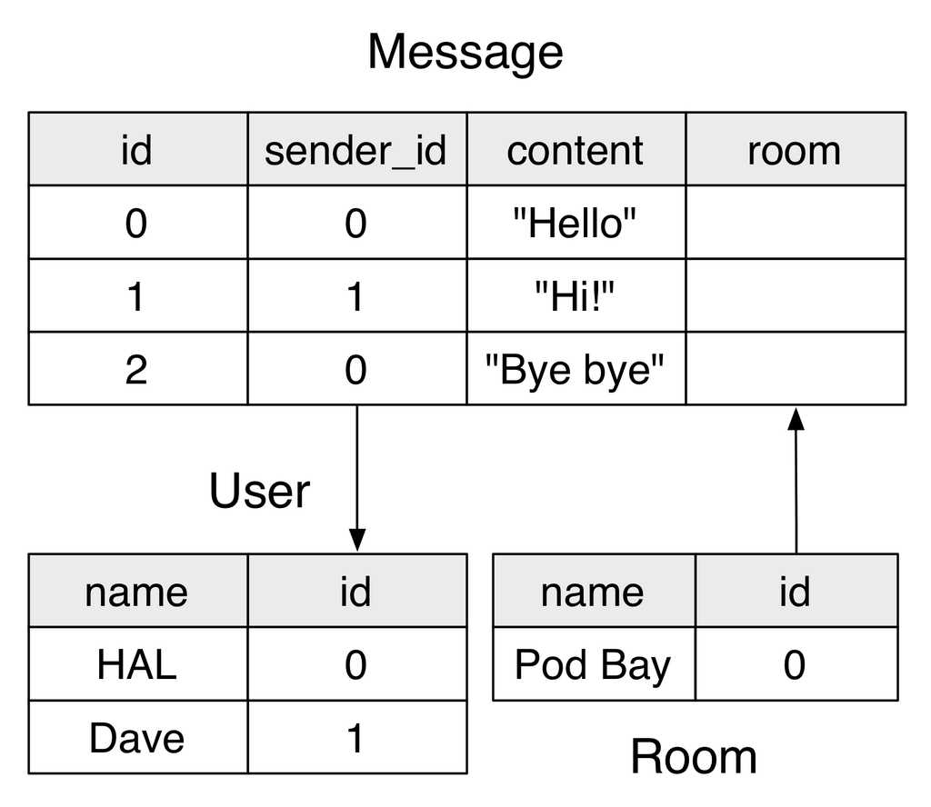

The database schema for this chapter. Find this code in the *chat-schema.scala* file of the example project on GitHub. A *message* can have a *sender*, which is a join to the *user* table. Also, a *message* can be in a *room*, which is a join to the *room* table.

For now we will add one more table. This is a `Room` that a `User` can be in, giving us channels for our chat conversations:

```scala
case class Room(title: String, id: Long = 0L)

class RoomTable(tag: Tag) extends Table[Room](tag, "room") {
  def id    = column[Long]("id", O.PrimaryKey, O.AutoInc)
  def title = column[String]("title")
  def * = (title, id).mapTo[Room]
}

lazy val rooms = TableQuery[RoomTable]
lazy val insertRoom = rooms returning rooms.map(_.id)
```

And we’ll modify a message so it can optionally be attached to a room:

```scala
case class Message(
  senderId : Long,
  content  : String,
  roomId   : Option[Long] = None,
  id       : Long = 0L)

class MessageTable(tag: Tag) extends Table[Message](tag, "message") {
  def id       = column[Long]("id", O.PrimaryKey, O.AutoInc)
  def senderId = column[Long]("senderId")
  def content  = column[String]("content")
  def roomId   = column[Option[Long]]("roomId")

  def sender = foreignKey("sender_fk", senderId, users)(_.id)
  def * = (senderId, content, roomId, id).mapTo[Message]
}

lazy val messages = TableQuery[MessageTable]
lazy val insertMessages = messages returning messages.map(_.id)
```

We’ll reset our database and populate it with some messages happening in the “Air Lock” room:

```scala
exec(messages.schema.drop)

val daveId = 1L
// daveId: Long = 1L
val halId  = 2L
// halId: Long = 2L

val setup = for {

  // Create the modified and new tables:
  _ <- (messages.schema ++ rooms.schema).create

  // Create one room:
  airLockId <- insertRoom += Room("Air Lock")

  // Half the messages will be in the air lock room...
  _ <- insertMessages += Message(daveId, "Hello, HAL. Do you read me, HAL?", Some(airLockId))
  _ <- insertMessages += Message(halId, "Affirmative, Dave. I read you.",   Some(airLockId))

  // ...and half will not be in room:
  _ <- insertMessages += Message(daveId, "Open the pod bay doors, HAL.")
  _ <- insertMessages += Message(halId, "I'm sorry, Dave. I'm afraid I can't do that.")

  // See what we end up with:
  msgs <- messages.result
} yield (msgs)
// setup: DBIOAction[Seq[MessageTable#TableElementType], NoStream, Effect.Schema with Effect.Write with Effect.Write with Effect.Write with Effect.Write with Effect.Write with Effect.Read] = FlatMapAction(
//   slick.jdbc.JdbcActionComponent$SchemaActionExtensionMethodsImpl$$anon$5@32fef27e,
//   <function1>,
//   scala.concurrent.impl.ExecutionContextImpl$$anon$3@25bc3124[Running, parallelism = 2, size = 1, active = 0, running = 0, steals = 89, tasks = 0, submissions = 0]
// )

exec(setup).foreach(println)
// Message(1,Hello, HAL. Do you read me, HAL?,Some(1),1)
// Message(2,Affirmative, Dave. I read you.,Some(1),2)
// Message(1,Open the pod bay doors, HAL.,None,3)
// Message(2,I'm sorry, Dave. I'm afraid I can't do that.,None,4)
```

Now let’s get to work and join across all these tables.

### 6.4.2 Inner Join

An inner join selects data from multiple tables, where the rows in each table match up in some way. Typically, the matching up is done by comparing primary keys. If there are rows that don’t match up, they won’t appear in the join results.

Let’s look up messages that have a sender in the user table, and a room in the rooms table:

```scala
val usersAndRooms =
  messages.
  join(users).on(_.senderId === _.id).
  join(rooms).on{ case ((msg,user), room) => msg.roomId === room.id }
// usersAndRooms: Query[((MessageTable, UserTable), RoomTable), ((MessageTable#TableElementType, UserTable#TableElementType), RoomTable#TableElementType), Seq] = Rep(Join Inner)
```

We’re joining `messages` to `users`, and `messages` to `rooms`. We use a binary function on the first call to `on` and a pattern matching function on our second call, to illustrate two styles.

Because each join results in a query of a tuple, successive joins result in nested tuples. Pattern matching is our preferred syntax for unpacking these tuples because it explicitly clarifies the structure of the query. However, you may see this more concisely expressed as a binary function for both joins:

```scala
val usersAndRoomsBinaryFunction =
  messages.
  join(users).on(_.senderId  === _.id).
  join(rooms).on(_._1.roomId === _.id)
// usersAndRoomsBinaryFunction: Query[((MessageTable, UserTable), RoomTable), ((MessageTable#TableElementType, UserTable#TableElementType), RoomTable#TableElementType), Seq] = Rep(Join Inner)
```

The result is the same either way.

#### 6.4.2.1 Mapping Joins

We can turn this query into an action as it stands:

```scala
val usersAndRoomQuery: DBIO[Seq[((Message, User), Room)]] =
  usersAndRooms.result
// usersAndRoomQuery: DBIO[Seq[((Message, User), Room)]] = slick.jdbc.JdbcActionComponent$QueryActionExtensionMethodsImpl$$anon$2@bf09ed6
```

…but our results will contain nested tuples. That’s OK, if that’s what you want. But typically we want to `map` over the query to flatten the results and select the columns we want.

Rather than returning the table classes, we can pick out just the information we want. Perhaps the message, the name of the sender, and the title of the room:

```scala
val usersAndRoomTitles =
  messages.
  join(users).on(_.senderId  === _.id).
  join(rooms).on { case ((msg,user), room) => msg.roomId === room.id }.
  map { case ((msg, user), room) => (msg.content, user.name, room.title) }
// usersAndRoomTitles: Query[(Rep[String], Rep[String], Rep[String]), (String, String, String), Seq] = Rep(Bind)

val action: DBIO[Seq[(String, String, String)]] = usersAndRoomTitles.result
// action: DBIO[Seq[(String, String, String)]] = slick.jdbc.JdbcActionComponent$QueryActionExtensionMethodsImpl$$anon$2@4f1e8c4

exec(action).foreach(println)
// (Hello, HAL. Do you read me, HAL?,Dave,Air Lock)
// (Affirmative, Dave. I read you.,HAL,Air Lock)
```

#### 6.4.2.2 Filter with Joins

As joins are queries, we can transform them using the combinators we learned in previous chapters. We’ve already seen an example of the `map` combinator. Another example would be the `filter` method.

As an example, we can use our `usersAndRooms` query and modify it to focus on a particular room. Perhaps we want to use our join for the Air Lock room:

```scala
// The query we've already seen...
val usersAndRooms =
  messages.
  join(users).on(_.senderId === _.id).
  join(rooms).on { case ((msg,user), room) => msg.roomId === room.id }
```

```scala
// ...modified to focus on one room:
val airLockMsgs =
  usersAndRooms.
  filter { case (_, room) => room.title === "Air Lock" }
// airLockMsgs: Query[((MessageTable, UserTable), RoomTable), ((MessageTable#TableElementType, UserTable#TableElementType), RoomTable#TableElementType), Seq] = Rep(Filter @1570678527)
```

As with other queries, the filter becomes a `WHERE` clause in SQL. Something like this:

```sql
SELECT
  "message"."content", "user"."name", "room"."title"
FROM
  "message"
  INNER JOIN "user" ON "message"."sender" = "user"."id"
  INNER JOIN "room" ON "message"."room"   = "room"."id"
WHERE
  "room"."title" = 'Air Lock';
```

### 6.4.3 Left Join

For an example from our chat schema, observe that messages can optionally be in a room. Let’s suppose we want a list of all the messages and the room they are sent to. Visually the left outer join is as shown below:

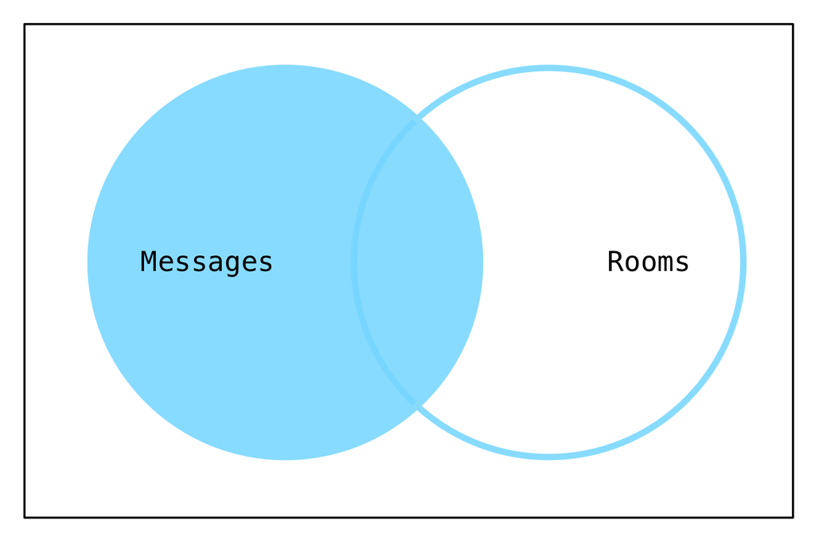

A visualization of the left outer join example. Selecting messages and associated rooms. For similar diagrams, see [A Visual Explanation of SQL Joins](https://blog.codinghorror.com/a-visual-explanation-of-sql-joins/), *Coding Horror*, 11 Oct 2007.

That is, we are going to select all the data from the messages table, plus data from the rooms table for those messages that are in a room.

The join would be:

```scala
val left = messages.joinLeft(rooms).on(_.roomId === _.id)
// left: Query[(MessageTable, Rep[Option[RoomTable]]), (MessageTable#TableElementType, Option[Room]), Seq] = Rep(Join LeftOption)
```

This query, `left`, is going to fetch messages and look up their corresponding room from the room table. Not all messages are in a room, so in that case the `roomId` column will be `NULL`.

Slick will lift those possibly null values into something more comfortable: `Option`. The full type of `left` is:

```scala
Query[
  (MessageTable, Rep[Option[RoomTable]]),
  (MessageTable#TableElementType, Option[Room]),
  Seq]
```

The results of this query are of type `(Message, Option[Room])`—Slick has made the `Room` side optional for us automatically.

If we want to just pick out the message content and the room title, we can `map` over the query:

```scala
val leftMapped =
  messages.
  joinLeft(rooms).on(_.roomId === _.id).
  map { case (msg, room) => (msg.content, room.map(_.title)) }
// leftMapped: Query[(Rep[String], Rep[Option[String]]), (String, Option[String]), Seq] = Rep(Bind)
```

Because the `room` element is optional, we naturally extract the `title` element using `Option.map`: `room.map(_.title)`.

The type of this query then becomes:

```scala
Query[
  (Rep[String], Rep[Option[String]]),
  (String, Option[String]),
  Seq]
```

The types `String` and `Option[String]` correspond to the message content and room title:

```scala
exec(leftMapped.result).foreach(println)
// (Hello, HAL. Do you read me, HAL?,Some(Air Lock))
// (Affirmative, Dave. I read you.,Some(Air Lock))
// (Open the pod bay doors, HAL.,None)
// (I'm sorry, Dave. I'm afraid I can't do that.,None)
```

### 6.4.4 Right Join

In the previous section, we saw that a left join selects all the records from the left hand side of the join, with possibly `NULL` values from the right.

Right joins (or right outer joins) reverse the situation, selecting all records from the right side of the join, with possibly `NULL` values from the left.

We can demonstrate this by reversing our left join example. We’ll ask for all rooms together with private messages have they received. We’ll use for comprehension syntax this time for variety:

```scala
val right = for {
  (msg, room) <- messages joinRight (rooms) on (_.roomId === _.id)
} yield (room.title, msg.map(_.content))
// right: Query[(Rep[String], Rep[Option[String]]), (String, Option[String]), Seq] = Rep(Bind)
```

Let’s create another room and see how the query works out:

```scala
exec(rooms += Room("Pod Bay"))
// res7: Int = 1

exec(right.result).foreach(println)
// (Air Lock,Some(Hello, HAL. Do you read me, HAL?))
// (Air Lock,Some(Affirmative, Dave. I read you.))
// (Pod Bay,None)
```

### 6.4.5 Full Outer Join

Full outer joins mean either side can be `NULL`.

From our schema an example would be the title of all rooms and messages in those rooms. Either side could be `NULL` because messages don’t have to be in rooms, and rooms don’t have to have any messages.

```scala
val outer = for {
  (room, msg) <- rooms joinFull messages on (_.id === _.roomId)
} yield (room.map(_.title), msg.map(_.content))
// outer: Query[(Rep[Option[String]], Rep[Option[String]]), (Option[String], Option[String]), Seq] = Rep(Bind)
```

The type of this query has options on either side:

```scala
Query[
  (Rep[Option[String]], Rep[Option[String]]),
  (Option[String], Option[String]),
  Seq]
```

As you can see from the results…

```scala
exec(outer.result).foreach(println)
// (Some(Air Lock),Some(Hello, HAL. Do you read me, HAL?))
// (Some(Air Lock),Some(Affirmative, Dave. I read you.))
// (Some(Pod Bay),None)
// (None,Some(Open the pod bay doors, HAL.))
// (None,Some(I'm sorry, Dave. I'm afraid I can't do that.))
```

…some rooms have many messages, some none, some messages have rooms, and some do not.

At the time of writing H2 does not support full outer joins. Whereas earlier versions of Slick would throw a runtime exception, Slick 3 compiles the query into something that will run, emulating a full outer join.

### 6.4.6 Cross Joins

In the examples above, whenever we’ve used `join` we’ve also used an `on` to constrain the join. This is optional.

If we omit the `on` condition for any `join`, `joinLeft`, or `joinRight`, we end up with a *cross join*.

Cross joins include every row from the left table with every row from the right table. If we have 10 rows in the first table and 5 in the second, the cross join produces 50 rows.

An example:

```scala
val cross = messages joinLeft users
// cross: slick.lifted.BaseJoinQuery[MessageTable, Rep[Option[UserTable]], MessageTable#TableElementType, Option[User], Seq, MessageTable, UserTable] = Rep(Join LeftOption)
```

## 6.5 Zip Joins

Zip joins are equivalent to `zip` on a Scala collection. Recall that the `zip` in the collections library operates on two lists and returns a list of pairs:

```scala
val xs = List(1, 2, 3)
// xs: List[Int] = List(1, 2, 3)

xs zip xs.drop(1)
// res10: List[(Int, Int)] = List((1, 2), (2, 3))
```

Slick provides the equivalent `zip` method for queries, plus two variations. Let’s say we want to pair up adjacent messages into what we’ll call a “conversation”:

```scala
// Select message content, ordered by id:
val msgs = messages.sortBy(_.id.asc).map(_.content)
// msgs: Query[Rep[String], String, Seq] = Rep(Bind)

// Pair up adjacent messages:
val conversations = msgs zip msgs.drop(1)
// conversations: Query[(Rep[String], Rep[String]), (String, String), Seq] = Rep(Join Zip)
```

This will turn into an inner join, producing output like:

```scala
exec(conversations.result).foreach(println)
// (Hello, HAL. Do you read me, HAL?,Affirmative, Dave. I read you.)
// (Affirmative, Dave. I read you.,Open the pod bay doors, HAL.)
// (Open the pod bay doors, HAL.,I'm sorry, Dave. I'm afraid I can't do that.)
```

A second variation, `zipWith`, lets us provide a mapping function along with the join. We can provide a function to upper-case the first part of a conversation, and lower-case the second part:

```scala
def combiner(c1: Rep[String], c2: Rep[String]) =
  (c1.toUpperCase, c2.toLowerCase)

val query = msgs.zipWith(msgs.drop(1), combiner)
// query: Query[(Rep[String], Rep[String]), (String, String), Seq] = Rep(Bind)

exec(query.result).foreach(println)
// (HELLO, HAL. DO YOU READ ME, HAL?,affirmative, dave. i read you.)
// (AFFIRMATIVE, DAVE. I READ YOU.,open the pod bay doors, hal.)
// (OPEN THE POD BAY DOORS, HAL.,i'm sorry, dave. i'm afraid i can't do that.)
```

The final variant is `zipWithIndex`, which is as per the Scala collections method of the same name. Let’s number each message:

```scala
val withIndexQuery = messages.map(_.content).zipWithIndex
// withIndexQuery: slick.lifted.BaseJoinQuery[Rep[String], Rep[Long], String, Long, Seq, Rep[String], Rep[Long]] = Rep(Join Zip)

val withIndexAction: DBIO[Seq[(String, Long)]] =
  withIndexQuery.result
// withIndexAction: DBIO[Seq[(String, Long)]] = slick.jdbc.JdbcActionComponent$QueryActionExtensionMethodsImpl$$anon$2@16291826
```

For H2 the SQL `ROWNUM()` function is used to generate a number. The data from this query will be:

```scala
exec(withIndexAction).foreach(println)
// (Hello, HAL. Do you read me, HAL?,0)
// (Affirmative, Dave. I read you.,1)
// (Open the pod bay doors, HAL.,2)
// (I'm sorry, Dave. I'm afraid I can't do that.,3)
```

Not all databases support zip joins. Check for the `relational.zip` capability in the `capabilities` field of your chosen database profile:

```scala
// H2 supports zip
slick.jdbc.H2Profile.capabilities.
  map(_.toString).
  contains("relational.zip")
// res14: Boolean = true
```

```scala
// SQLite does not support zip
slick.jdbc.SQLiteProfile.capabilities.
  map(_.toString).
  contains("relational.zip")
// res15: Boolean = false
```

## 6.6 Joins Summary

In this chapter we’ve seen examples of the two different styles of join: applicative and monadic. We’ve also mixed and matched these styles.

We’ve seen how to construct the arguments to `on` methods, either with a binary join condition or by deconstructing a tuple with pattern matching.

Each join step produces a tuple. Using pattern matching in `map` and `filter` allows us to clearly name each part of the tuple, especially when the tuple is deeply nested.

We’ve also explored inner and outer joins, zip joins, and cross joins. We saw that each type of join is a query, making it compatible with combinators such as `map` and `filter` from earlier chapters.

## 6.7 Seen Any Strange Queries?

If you’ve been following along and running the example joins, you may have noticed large or unusual queries being generated. Or you may not have. Since Slick 3.1, the SQL generated by Slick has improved greatly.

However, you may find the SQL generated a little strange or involved. If Slick generates verbose queries are they are going to be slow?

Here’s the key concept: the SQL generated by Slick is fed to the database optimizer. That optimizer has far better knowledge about your database, indexes, query paths, than anything else. It will optimize the SQL from Slick into something that works well.

Unfortunately, some optimizers don’t manage this very well. Postgres does a good job. MySQL is, at the time of writing, pretty bad at this. The trick here is to watch for slow queries, and use your database’s `EXPLAIN` command to examine and debug the query plan.

Optimisations can often be achieved by rewriting monadic joins in applicative style and judiciously adding indices to the columns involved in joins. However, a full discussion of query optimisation is out of the scope of this book. See your database’s documentation for more information.

If all else fails, we can rewrite queries for ultimate control using Slick’s *Plain SQL* feature. We will look at this in Chapter 7.

## 6.8 Aggregation

Aggregate functions are all about computing a single value from some set of rows. A simple example is `count`. This section looks at aggregation, and also at grouping rows, and computing values on those groups.

### 6.8.1 Functions

Slick provides a few aggregate functions, as listed in the table below.

A Selection of Aggregate Functions

| Method | SQL |
| --- | --- |
| `length` | `COUNT(1)` |
| `min` | `MIN(column)` |
| `max` | `MAX(column)` |
| `sum` | `SUM(column)` |
| `avg` | `AVG(column)` — mean of the column values |

Using them causes no great surprises, as shown in the following examples:

```scala
val numRows: DBIO[Int] = messages.length.result
// numRows: DBIO[Int] = slick.jdbc.JdbcActionComponent$QueryActionExtensionMethodsImpl$$anon$3@4db94010

val numDifferentSenders: DBIO[Int] =
  messages.map(_.senderId).distinct.length.result
// numDifferentSenders: DBIO[Int] = slick.jdbc.JdbcActionComponent$QueryActionExtensionMethodsImpl$$anon$3@7eded864

val firstSent: DBIO[Option[Long]] =
  messages.map(_.id).min.result
// firstSent: DBIO[Option[Long]] = slick.jdbc.JdbcActionComponent$QueryActionExtensionMethodsImpl$$anon$3@6a72b74f
```

While `length` returns an `Int`, the other functions return an `Option`. This is because there may be no rows returned by the query, meaning there is no minimum, no maximum and so on.

### 6.8.2 Grouping

Aggregate functions are often used with column grouping. For example, how many messages has each user sent? That’s a grouping (by user) of an aggregate (count).

#### 6.8.2.1 `groupBy`

Slick provides `groupBy` which will group rows by some expression. Here’s an example:

```scala
val msgPerUser: DBIO[Seq[(Long, Int)]] =
  messages.groupBy(_.senderId).
  map { case (senderId, msgs) => senderId -> msgs.length }.
  result
// msgPerUser: DBIO[Seq[(Long, Int)]] = slick.jdbc.JdbcActionComponent$QueryActionExtensionMethodsImpl$$anon$2@34447a0f
```

A `groupBy` must be followed by a `map`. The input to the `map` will be the grouping key (`senderId`) and a query for the group.

When we run the query, it’ll work, but it will be in terms of a user’s primary key:

```scala
exec(msgPerUser)
// res18: Seq[(Long, Int)] = Vector((1L, 2), (2L, 2))
```

#### 6.8.2.2 Groups and Joins

It’d be nicer to see the user’s name. We can do that using our join skills:

```scala
val msgsPerUser =
   messages.join(users).on(_.senderId === _.id).
   groupBy { case (msg, user)   => user.name }.
   map     { case (name, group) => name -> group.length }.
   result
// msgsPerUser: slick.jdbc.H2Profile.StreamingProfileAction[Seq[(String, Int)], (String, Int), Effect.Read] = slick.jdbc.JdbcActionComponent$QueryActionExtensionMethodsImpl$$anon$2@33fa1557
```

The results would be:

```scala
exec(msgsPerUser).foreach(println)
// (Dave,2)
// (HAL,2)
```

So what’s happened here? What `groupBy` has given us is a way to place rows into groups according to some function we supply. In this example the function is to group rows based on the user’s name. It doesn’t have to be a `String`, it could be any type in the table.

When it comes to mapping, we now have the key to the group (the user’s name in our case), and the corresponding group rows *as a query*.

Because we’ve joined messages and users, our group is a query of those two tables. In this example we don’t care what the query is because we’re just counting the number of rows. But sometimes we will need to know more about the query.

#### 6.8.2.3 More Complicated Grouping

Let’s look at a more involved example by collecting some statistics about our messages. We want to find, for each user, how many messages they sent, and the id of their first message. We want a result something like this:

```scala
Vector(
  (HAL,   2, Some(2)),
  (Dave,  2, Some(1)))
```

We have all the aggregate functions we need to do this:

```scala
val stats =
   messages.join(users).on(_.senderId === _.id).
   groupBy { case (msg, user) => user.name }.
   map     {
    case (name, group) =>
      (name, group.length, group.map{ case (msg, user) => msg.id}.min)
   }
// stats: Query[(Rep[String], Rep[Int], Rep[Option[Long]]), (String, Int, Option[Long]), Seq] = Rep(Bind)
```

We’ve now started to create a bit of a monster query. We can simplify this, but before doing so, it may help to clarify that this query is equivalent to the following SQL:

```sql
select
  user.name, count(1), min(message.id)
from
  message inner join user on message.sender = user.id
group by
  user.name
```

Convince yourself the Slick and SQL queries are equivalent, by comparing:

- the `map` expression in the Slick query to the `SELECT` clause in the SQL;
- the `join` to the SQL `INNER JOIN`; and
- the `groupBy` to the SQL `GROUP` expression.

If you do that you’ll see the Slick expression makes sense. But when seeing these kinds of queries in code it may help to simplify by introducing intermediate functions with meaningful names.

There are a few ways to go at simplifying this, but the lowest hanging fruit is that `min` expression inside the `map`. The issue here is that the `group` pattern is a `Query` of `(MessageTable, UserTable)` as that’s our join. That leads to us having to split it further to access the message’s ID field.

Let’s pull that part out as a method:

```scala
import scala.language.higherKinds

def idOf[S[_]](group: Query[(MessageTable,UserTable), (Message,User), S]) =
    group.map { case (msg, user) => msg.id }
```

What we’ve done here is introduced a method to work on the group query, using the knowledge of the `Query` type introduced in The Query and TableQuery Types section of Chapter 2.

The query (`group`) is parameterized by thee things: the join, the unpacked values, and the container for the results. By container we mean something like `Seq[T]`. We don’t really care what our results go into, but we do care we’re working with messages and users.

With this little piece of domain specific language in place, the query becomes:

```scala
val nicerStats =
   messages.join(users).on(_.senderId === _.id).
   groupBy { case (msg, user)   => user.name }.
   map     { case (name, group) => (name, group.length, idOf(group).min) }
// nicerStats: Query[(Rep[String], Rep[Int], Rep[Option[Long]]), (String, Int, Option[Long]), Seq] = Rep(Bind)

exec(nicerStats.result).foreach(println)
// (Dave,2,Some(1))
// (HAL,2,Some(2))
```

We think these small changes make code more maintainable and, quite frankly, less scary. It may be marginal in this case, but real world queries can become large. Your team mileage may vary, but if you see Slick queries that are hard to understand, try pulling the query apart into named methods.

**Group By True**

There’s a `groupBy { _ => true}` trick you can use where you want to select more than one aggregate from a query.

As an example, have a go at translating this SQL into a Slick query:

```sql
select min(id), max(id) from message where content like '%read%'
```

It’s pretty easy to get either `min` or `max`:

```scala
messages.filter(_.content like "%read%").map(_.id).min
// res21: Rep[Option[Long]] = Rep(Apply Function min)
```

But you want both `min` and `max` in one query. This is where `groupBy { _ => true}` comes into play:

```scala
messages.
 filter(_.content like "%read%").
 groupBy(_ => true).
 map {
  case (_, msgs) => (msgs.map(_.id).min, msgs.map(_.id).max)
}
// res22: Query[(Rep[Option[Long]], Rep[Option[Long]]), (Option[Long], Option[Long]), Seq] = Rep(Bind)
```

The effect of `_ => true` here is to group all rows into the same group! This allows us to reuse the `msgs` query, and obtain the result we want.

#### 6.8.2.4 Grouping by Multiple Columns

The result of `groupBy` doesn’t need to be a single value: it can be a tuple. This gives us access to grouping by multiple columns.

We can look at the number of messages per user per room. Something like this:

```scala
Vector(
  (Air Lock, HAL,   1),
  (Air Lock, Dave,  1),
  (Kitchen,  Frank, 3) )
```

…assuming we add a message from Frank:

```scala
val addFrank = for {
  kitchenId <- insertRoom += Room("Kitchen")
  frankId   <- insertUser += User("Frank")
  rowsAdded <- messages ++= Seq(
    Message(frankId, "Hello?",    Some(kitchenId)),
    Message(frankId, "Helloooo?", Some(kitchenId)),
    Message(frankId, "HELLO!?",   Some(kitchenId))
  )
} yield rowsAdded
// addFrank: DBIOAction[Option[Int], NoStream, Effect.Write with Effect.Write with Effect.Write] = FlatMapAction(
//   slick.jdbc.JdbcActionComponent$InsertActionComposerImpl$SingleInsertAction@74f605b1,
//   <function1>,
//   scala.concurrent.impl.ExecutionContextImpl$$anon$3@25bc3124[Running, parallelism = 2, size = 1, active = 0, running = 0, steals = 89, tasks = 0, submissions = 0]
// )

exec(addFrank)
// res23: Option[Int] = Some(3)
```

To run the report we’re going to need to group by room and then by user, and finally count the number of rows in each group:

```scala
val msgsPerRoomPerUser =
   rooms.
   join(messages).on(_.id === _.roomId).
   join(users).on{ case ((room,msg), user) => user.id === msg.senderId }.
   groupBy { case ((room,msg), user)   => (room.title, user.name) }.
   map     { case ((room,user), group) => (room, user, group.length) }.
   sortBy  { case (room, user, group)  => room }
// msgsPerRoomPerUser: Query[(Rep[String], Rep[String], Rep[Int]), (String, String, Int), Seq] = Rep(SortBy Ordering(Asc,NullsDefault))
```

Hopefully you’re now in a position where you can unpick this:

- We join on messages, room and user to be able to display the room title and user name.
- The value passed into the `groupBy` will be determined by the join.
- The result of the `groupBy` is the columns for the grouping, which is a tuple of the room title and the user’s name.
- We select (`map`) just the columns we want: room, user and the number of rows.
- For fun we’ve thrown in a `sortBy` to get the results in room order.

Running the action produces our expected report:

```scala
exec(msgsPerRoomPerUser.result).foreach(println)
// (Air Lock,Dave,1)
// (Air Lock,HAL,1)
// (Kitchen,Frank,3)
```

## 6.9 Take Home Points

Aggregation methods, such as `length` and `sum`, produce a value from a set of rows.

Rows can be grouped based on an expression supplied to `groupBy`. The result of a grouping expression is a group key and a query defining the group. Use `map`, `filter`, `sortBy` as you would with any query in Slick.

The SQL produced by Slick might not be the SQL you would write. Slick expects the database query engine to perform optimisation. If you find slow queries, take a look at *Plain SQL*, discussed in the next chapter.

## 6.10 Exercises

Because these exercises are all about multiple tables, take a moment to remind yourself of the schema. You’ll find this in the example code, `chatper-06`, in the source file `chat_schema.scala`.

### 6.10.1 Name of the Sender

Each message is sent by someone. That is, the `messages.senderId` will have a matching row via `users.id`.

Please…

- Write a monadic join to return all `Message` rows and the associated `User` record for each of them.
- Change your answer to return only the content of a message and the name of the sender.
- Modify the query to return the results in name order.
- Re-write the query as an applicative join.

These exercises will get your fingers familiar with writing joins.

These queries are all items we’ve covered in the text:

```scala
val ex1 = for {
  m <- messages
  u <- users
  if u.id === m.senderId
} yield (m, u)
// ex1: Query[(MessageTable, UserTable), (Message, User), Seq] = Rep(Bind)

val ex2 = for {
  m <- messages
  u <- users
  if u.id === m.senderId
} yield (m.content, u.name)
// ex2: Query[(Rep[String], Rep[String]), (String, String), Seq] = Rep(Bind)

val ex3 = ex2.sortBy{ case (content, name) => name }
// ex3: Query[(Rep[String], Rep[String]), (String, String), Seq] = Rep(SortBy Ordering(Asc,NullsDefault))

val ex4 =
  messages.
   join(users).on(_.senderId === _.id).
   map    { case (msg, usr)     => (msg.content, usr.name) }.
   sortBy { case (content,name) => name }
// ex4: Query[(Rep[String], Rep[String]), (String, String), Seq] = Rep(SortBy Ordering(Asc,NullsDefault))
```

### 6.10.2 Messages of the Sender

Write a method to fetch all the message sent by a particular user. The signature is:

```scala
def findByName(name: String): Query[Rep[Message], Message, Seq] = ???
```

This is a filter, a join, and a map:

```scala
def findByNameMonadic(name: String): Query[Rep[Message], Message, Seq] = for {
  u <- users    if u.name === name
  m <- messages if m.senderId === u.id
} yield m
```

…or…

```scala
def findByNameApplicative(name: String): Query[Rep[Message], Message, Seq] =
  users.filter(_.name === name).
  join(messages).on(_.id === _.senderId).
  map{ case (user, msg) => msg }
```

### 6.10.3 Having Many Messages

Modify the `msgsPerUser` query…

```scala
val msgsPerUser =
   messages.join(users).on(_.senderId === _.id).
   groupBy { case (msg, user)  => user.name }.
   map     { case (name, group) => name -> group.length }
```

…to return the counts for just those users with more than 2 messages.

SQL distinguishes between `WHERE` and `HAVING`. In Slick you use `filter` for both:

```scala
val modifiedMsgsPerUser =
   messages.join(users).on(_.senderId === _.id).
   groupBy { case (msg, user)  => user.name }.
   map     { case (name, group) => name -> group.length }.
   filter  { case (name, count) => count > 2 }
// modifiedMsgsPerUser: Query[(Rep[String], Rep[Int]), (String, Int), Seq] = Rep(Filter @411056163)
```

At this point in the book, only Frank has more than two messages:

```scala
exec(modifiedMsgsPerUser.result)
// res25: Seq[(String, Int)] = Vector(("Frank", 3))

// Let's check:
val frankMsgs =
  messages.join(users).on {
    case (msg,user) => msg.senderId === user.id && user.name === "Frank"
  }
// frankMsgs: Query[(MessageTable, UserTable), (MessageTable#TableElementType, UserTable#TableElementType), Seq] = Rep(Join Inner)

exec(frankMsgs.result).foreach(println)
// (Message(3,Hello?,Some(3),5),User(Frank,3))
// (Message(3,Helloooo?,Some(3),6),User(Frank,3))
// (Message(3,HELLO!?,Some(3),7),User(Frank,3))
```

…although if you’ve been experimenting with the database, your results could be different.

### 6.10.4 Collecting Results

A join on messages and senders will produce a row for every message. Each row will be a tuple of the user and message:

```scala
users.join(messages).on(_.id === _.senderId)
// res1: slick.lifted.Query[
//  (UserTable, MessageTable),
//  (UserTable#TableElementType, MessageTable#TableElementType),
//  Seq] = Rep(Join Inner)
```

The return type is effectively `Seq[(User, Message)]`.

Sometimes you’ll really want something like a `Map[User, Seq[Message]]`.

There’s no built-in way to do that in Slick, but you can do it in Scala using the collections `groupBy` method.

```scala
val almost = Seq(
  ("HAL"  -> "Hello"),
  ("Dave" -> "How are you?"),
  ("HAL"  -> "I have terrible pain in all the diodes")
  ).groupBy{ case (name, message) => name }
// almost: Map[String, Seq[(String, String)]] = HashMap(
//   "HAL" -> List(("HAL", "Hello"), ("HAL", "I have terrible pain in all the diodes")),
//   "Dave" -> List(("Dave", "How are you?"))
// )
```

That’s close, but the values in the map are still a tuple of the name and the message. We can go further and reduce this to:

```scala
val correct = almost.view.mapValues { values =>
  values.map{ case (name, msg) => msg }
}
```

```scala
correct.foreach(println)
// (HAL,List(Hello, I have terrible pain in all the diodes))
// (Dave,List(How are you?))
```

The `.view` call is required in Scala 2.13 to convert the lazy evaluated map into a strict map. A future version of Scala will remove the need for the `.view` call.

Go ahead and write a method to encapsulate this for a join:

```scala
def userMessages: DBIO[Map[User, Seq[Message]]] = ???
```

You need all the code in the question and also what you know about action combinators:

```scala
def userMessages: DBIO[Map[User,Seq[Message]]] =
  users.join(messages).on(_.id === _.senderId).result.
  map { rows => rows
    .groupBy{ case (user, message) => user }
    .view
    .mapValues(values => values.map{ case (name, msg) => msg })
    .toMap
  }

exec(userMessages).foreach(println)
// (User(Dave,1),Vector(Message(1,Hello, HAL. Do you read me, HAL?,Some(1),1), Message(1,Open the pod bay doors, HAL.,None,3)))
// (User(HAL,2),Vector(Message(2,Affirmative, Dave. I read you.,Some(1),2), Message(2,I'm sorry, Dave. I'm afraid I can't do that.,None,4)))
// (User(Frank,3),Vector(Message(3,Hello?,Some(3),5), Message(3,Helloooo?,Some(3),6), Message(3,HELLO!?,Some(3),7)))
```

You may have been tripped up on the call to `toMap` at the end. We didn’t need this in the examples in the text because we were not being explicit that we wanted a `Map[User,Seq[Message]]`. However, `userMessages` does define the result type, and as such we need to explicitly covert the sequence of tuples into a `Map`.

# 7 Plain SQL

Slick supports Plain SQL queries in addition to the lifted embedded style we’ve seen up to this point. Plain queries don’t compose as nicely as lifted, or offer quite the same type safely. But they enable you to execute essentially arbitrary SQL when you need to. If you’re unhappy with a particular query produced by Slick, dropping into Plain SQL is the way to go.

In this section we will see that:

- the [interpolators](https://docs.scala-lang.org/overviews/core/string-interpolation.html) `sql` (for select) and `sqlu` (for updates) are used to create Plain SQL queries;
- values can be safely substituted into queries using a `${expresson}` syntax;
- custom types can be used in Plain SQL, as long as there is a converter in scope; and
- the `tsql` interpolator can be used to check the syntax and types of a query via a database at compile time.

**A Table to Work With**

For the examples that follow, we’ll set up a table for rooms. For now we’ll do this as we have in other chapters using the lifted embedded style:

```scala
case class Room(title: String, id: Long = 0L)

class RoomTable(tag: Tag) extends Table[Room](tag, "room") {
 def id    = column[Long]("id", O.PrimaryKey, O.AutoInc)
 def title = column[String]("title")
 def * = (title, id).mapTo[Room]
}

lazy val rooms = TableQuery[RoomTable]

val roomSetup = DBIO.seq(
  rooms.schema.create,
  rooms ++= Seq(Room("Air Lock"), Room("Pod"), Room("Brain Room"))
)
// roomSetup: DBIOAction[Unit, NoStream, Effect.Write with Effect.Schema] = slick.dbio.DBIOAction$$anon$4@4f62c765

val setupResult = exec(roomSetup)
```

## 7.1 Selects

Let’s start with a simple example of returning a list of room IDs.

```scala
val action = sql""" select "id" from "room" """.as[Long]
// action: slick.sql.SqlStreamingAction[Vector[Long], Long, Effect] = slick.jdbc.SQLActionBuilder$$anon$1@b1188ed

Await.result(db.run(action), 2.seconds)
// res0: Vector[Long] = Vector(1L, 2L, 3L)
```

Running a Plain SQL query looks similar to other queries we’ve seen in this book: call `db.run` as usual.

The big difference is with the construction of the query. We supply both the SQL we want to run and specify the expected result type using `as[T]`. And the result we get back is an action to run, rather than a `Query`.

The `as[T]` method is pretty flexible. Let’s get back the room ID and room title:

```scala
val roomInfo = sql""" select "id", "title" from "room" """.as[(Long,String)]
// roomInfo: slick.sql.SqlStreamingAction[Vector[(Long, String)], (Long, String), Effect] = slick.jdbc.SQLActionBuilder$$anon$1@75ef6d35

exec(roomInfo)
// res1: Vector[(Long, String)] = Vector(
//   (1L, "Air Lock"),
//   (2L, "Pod"),
//   (3L, "Brain Room")
// )
```

Notice we specified a tuple of `(Long, String)` as the result type. This matches the columns in our SQL `SELECT` statement.

Using `as[T]` we can build up arbitrary result types. Later we’ll see how we can use our own application case classes too.

One of the most useful features of the SQL interpolators is being able to reference Scala values in a query:

```scala
val roomName = "Pod"
// roomName: String = "Pod"

val podRoomAction = sql"""
  select
    "id", "title"
  from
    "room"
  where
    "title" = $roomName """.as[(Long,String)].headOption
// podRoomAction: slick.sql.SqlStreamingAction[Vector[(Long, String)], (Long, String), Effect]#ResultAction[Option[(Long, String)], NoStream, Effect] = slick.jdbc.StreamingInvokerAction$HeadOptionAction@10621048

exec(podRoomAction)
// res2: Option[(Long, String)] = Some((2L, "Pod"))
```

Notice how `$roomName` is used to reference a Scala value `roomName`. This value is incorporated safely into the query. That is, you don’t have to worry about SQL injection attacks when you use the SQL interpolators in this way.

**The Danger of Strings**

The SQL interpolators are essential for situations where you need full control over the SQL to be run. Be aware there is some loss of compile-time safety. For example:

```scala
val t = 42
// t: Int = 42

val badAction =
  sql""" select "id" from "room" where "title" = $t """.as[Long]
// badAction: slick.sql.SqlStreamingAction[Vector[Long], Long, Effect] = slick.jdbc.SQLActionBuilder$$anon$1@49e2a4ce
```

This compiles, but fails at runtime as the type of the `title` column is a `String` and we’ve provided an `Int`:

```scala
exec(badAction.asTry)
// res3: util.Try[Vector[Long]] = Failure(
//   org.h2.jdbc.JdbcSQLDataException: Data conversion error converting "Air Lock"; SQL statement:
//  select "id" from "room" where "title" = ?  [22018-200]
// )
```

The equivalent query using the lifted embedded style would have caught the problem at compile time. The `tsql` interpolator, described later in this chapter, helps here by connecting to a database at compile time to check the query and types.

Another danger is with the `#$` style of substitution. This is called *splicing*, and is used when you *don’t* want SQL escaping to apply. For example, perhaps the name of the table you want to use may change:

```scala
val table = "room"
// table: String = "room"
val splicedAction = sql""" select "id" from "#$table" """.as[Long]
// splicedAction: slick.sql.SqlStreamingAction[Vector[Long], Long, Effect] = slick.jdbc.SQLActionBuilder$$anon$1@4e330bff
```

This means you can produce unsafe SQL with splicing. The golden rule is to never use `#$` with input supplied by users.

To be sure you remember it, say it again with us: never use `#$` with input supplied by users.

### 7.1.1 Select with Custom Types

Out of the box Slick knows how to convert many data types to and from SQL data types. The examples we’ve seen so far include turning a Scala `String` into a SQL string, and a SQL BIGINT to a Scala `Long`. These conversions are available via `as[T]`.

If we want to work with a type that Slick doesn’t know about, we need to provide a conversion. That’s the role of the `GetResult` type class.

For an example, let’s set up a table for messages with some interesting structure:

```scala
import org.joda.time.DateTime

case class Message(
  sender  : String,
  content : String,
  created : DateTime,
  updated : Option[DateTime],
  id      : Long = 0L
)
```

The point of interest for the moment is that we have a `created` field of type `DateTime`. This is from Joda Time, and Slick does not ship with built-in support for this type.

This is the query we want to run:

```scala
sql""" select "created" from "message" """.as[DateTime]
// error: could not find implicit value for parameter rconv: slick.jdbc.GetResult[org.joda.time.DateTime] (No implicit view available from slick.jdbc.PositionedResult => org.joda.time.DateTime.)
// sql""" select "created" from "message" """.as[DateTime]
// ^^^^^^^^^^^^^^^^^^^^^^^^^^^^^^^^^^^^^^^^^^^^^^^^^^^^^^^
```

OK, that won’t compile as Slick doesn’t know anything about `DateTime`. For this to compile we need to provide an instance of `GetResult[DateTime]`:

```scala
import slick.jdbc.GetResult
import java.sql.Timestamp
import org.joda.time.DateTimeZone.UTC
```

```scala
implicit val GetDateTime =
  GetResult[DateTime](r => new DateTime(r.nextTimestamp(), UTC))
// GetDateTime: AnyRef with GetResult[DateTime] = <function1>
```

`GetResult` is wrapping up a function from `r` (a `PositionedResult`) to `DateTime`. The `PositionedResult` provides access to the database value (via `nextTimestamp`, `nextLong`, `nextBigDecimal` and so on). We use the value from `nextTimestamp` to feed into the constructor for `DateTime`.

The name of this value doesn’t matter. What’s important is that the value is implicit and the type is `GetResult[DateTime]`. This allows the compiler to lookup our conversion function when we mention a `DateTime`.

Now we can construct our action:

```scala
sql""" select "created" from "message" """.as[DateTime]
// res5: slick.sql.SqlStreamingAction[Vector[DateTime], DateTime, Effect] = slick.jdbc.SQLActionBuilder$$anon$1@5299ca16
```

### 7.1.2 Case Classes

As you’ve probably guessed, returning a case class from a Plain SQL query means providing a `GetResult` for the case class. Let’s work through an example for the messages table.

Recall that a message contains: an ID, some content, the sender ID, a timestamp, and an optional timestamp.

To provide a `GetResult[Message]` we need all the types inside the `Message` to have `GetResult` instances. We’ve already tackled `DateTime`. And Slick knows how to handle `Long` and `String`. So that leaves us with `Option[DateTime]` and the `Message` itself.

For optional values, Slick provides `nextXXXOption` methods, such as `nextLongOption`. For the optional date time we read the database value using `nextTimestampOption()` and then `map` to the right type:

```scala
implicit val GetOptionalDateTime = GetResult[Option[DateTime]](r =>
  r.nextTimestampOption().map(ts => new DateTime(ts, UTC))
)
// GetOptionalDateTime: AnyRef with GetResult[Option[DateTime]] = <function1>
```

With all the individual columns mapped we can pull them together in a `GetResult` for `Message`. There are two helper methods which make it easier to construct these instances:

- `<<` for calling the appropriate *nextXXX* method; and
- `<<?` when the value is optional.

We can use them like this:

```scala
implicit val GetMessage = GetResult(r =>
   Message(sender  = r.<<,
           content = r.<<,
           created = r.<<,
           updated = r.<<?,
           id      = r.<<)
 )
// GetMessage: AnyRef with GetResult[Message] = <function1>
```

This works because we’ve provided implicits for the components of the case class. As the types of the fields are known, `<<` and `<<?` can use the implicit `GetResult[T]` for the type of each type.

Now we can select into `Message` values:

```scala
val messageAction: DBIO[Seq[Message]] =
  sql""" select * from "message" """.as[Message]
// messageAction: DBIO[Seq[Message]] = slick.jdbc.SQLActionBuilder$$anon$1@77c84a5a
```

In all likelihood you’ll prefer the lifted embedded style over Plain SQL in this specific example. But if you do find yourself using Plain SQL, for performance reasons perhaps, it’s useful to know how to convert database values up into meaningful domain types.

**`SELECT *`**

We sometimes use `SELECT *` in this chapter to fit our code examples onto the page. You should avoid this in your code base as it leads to brittle code.

An example: if, outside of Slick, a table is modified to add a column, the results from the query will unexpectedly change. You code may not longer be able to map results.

## 7.2 Updates

Back in Chapter 3 we saw how to modify rows with the `update` method. We noted that batch updates were challenging when we wanted to use the row’s current value. The example we used was appending an exclamation mark to a message’s content:

```sql
UPDATE "message" SET "content" = CONCAT("content", '!')
```

Plain SQL updates will allow us to do this. The interpolator is `sqlu`:

```scala
val updateAction =
  sqlu"""UPDATE "message" SET "content" = CONCAT("content", '!')"""
// updateAction: slick.sql.SqlAction[Int, NoStream, Effect] = slick.jdbc.StreamingInvokerAction$HeadAction@4459e818
```

The `action` we have constructed, just like other actions, is not run until we evaluate it via `db.run`. But when it is run, it will append the exclamation mark to each row value, which is what we couldn’t do as efficiently with the lifted embedded style.

Just like the `sql` interpolator, we also have access to `$` for binding to variables:

```scala
val char = "!"
// char: String = "!"
val interpolatorAction =
  sqlu"""UPDATE "message" SET "content" = CONCAT("content", $char)"""
// interpolatorAction: slick.sql.SqlAction[Int, NoStream, Effect] = slick.jdbc.StreamingInvokerAction$HeadAction@18a528f7
```

This gives us two benefits: the compiler will point out typos in variables names, but also the input is sanitized against [SQL injection attacks](https://en.wikipedia.org/wiki/SQL_injection).

In this case, the statement that Slick generates will be:

```scala
interpolatorAction.statements.head
// res6: String = "UPDATE \"message\" SET \"content\" = CONCAT(\"content\", ?)"
```

### 7.2.1 Updating with Custom Types

Working with basic types like `String` and `Int` is fine, but sometimes you want to update using a richer type. We saw the `GetResult` type class for mapping select results, and for updates this is mirrored with the `SetParameter` type class.

We can teach Slick how to set `DateTime` parameters like this:

```scala
import slick.jdbc.SetParameter

implicit val SetDateTime = SetParameter[DateTime](
  (dt, pp) => pp.setTimestamp(new Timestamp(dt.getMillis))
 )
// SetDateTime: AnyRef with SetParameter[DateTime] = <function2>
```

The value `pp` is a `PositionedParameters`. This is an implementation detail of Slick, wrapping a SQL statement and a placeholder for a value. Effectively we’re saying how to treat a `DateTime` regardless of where it appears in the update statement.

In addition to a `Timestamp` (via `setTimestamp`), you can set: `Boolean`, `Byte`, `Short`, `Int`, `Long`, `Float`, `Double`, `BigDecimal`, `Array[Byte]`, `Blob`, `Clob`, `Date`, `Time`, as well as `Object` and `null`. There are *setXXX* methods on `PositionedParameters` for `Option` types, too.

There’s further symmetry with `GetResuts` in that we could have used `>>` in our `SetParameter`:

```scala
implicit val SetDateTime = SetParameter[DateTime](
  (dt, pp) => pp >> new Timestamp(dt.getMillis))
// SetDateTime: AnyRef with SetParameter[DateTime] = <function2>
```

With this in place we can construct Plain SQL updates using `DateTime` instances:

```scala
val now =
  sqlu"""UPDATE "message" SET "created" = ${DateTime.now}"""
// now: slick.sql.SqlAction[Int, NoStream, Effect] = slick.jdbc.StreamingInvokerAction$HeadAction@4f0988f
```

Without the `SetParameter[DateTime]` instance the compiler would tell you:

```scala
could not find implicit SetParameter[DateTime]
```

## 7.3 Typed Checked Plain SQL

We’ve mentioned the risks of Plain SQL, which can be summarized as not discovering a problem with your query until runtime. The `tsql` interpolator removes some of this risk, but at the cost of requiring a connection to a database at compile time.

**Run the Code**

These examples won’t run in the REPL. To try these out, use the `tsql.scala` file inside the `chapter-07` folder. This is all in the [example code base on GitHub](https://github.com/underscoreio/essential-slick-code/tree/3.3).

### 7.3.1 Compile Time Database Connections

To get started with `tsql` we provide a database configuration information on a class:

```scala
import slick.backend.StaticDatabaseConfig

@StaticDatabaseConfig("file:src/main/resources/application.conf#tsql")
object TsqlExample {
  // queries go here
}
```

The `@StaticDatabaseConfig` syntax is called an *annotation*. This particular `StaticDatabaseConfig` annotation is telling Slick to use the connection called “tsql” in our configuration file. That entry will look like this:

```scala
tsql {
  profile = "slick.jdbc.H2Profile$"
  db {
    connectionPool = disabled
    url = "jdbc:h2:mem:chapter06; INIT=
       runscript from 'src/main/resources/integration-schema.sql'"
    driver = "org.h2.Driver"
    keepAliveConnection = false
  }
}
```

Note the `$` in the profile class name is not a typo. The class name is being passed to Java’s `Class.forName`, but of course Java doesn’t have a singleton as such. The Slick configuration does the right thing to load `$MODULE` when it sees `$`. This interoperability with Java is described in [Chapter 29 of *Programming in Scala*](https://www.artima.com/pins1ed/combining-scala-and-java.html#i-855208314-1).

You won’t have seen this when we introduced the database configuration in Chapter 1. That’s because this `tsql` configuration has a different format, and combines the Slick profile (`slick.jdbc.H2Profile`) and the JDBC driver (`org.h2.Drvier`) in one entry.

A consequence of supplying a `@StaticDatabaseConfig` is that you can define one databases configuration for your application and a different one for the compiler to use. That is, perhaps you are running an application, or test suite, against an in-memory database, but validating the queries at compile time against a full-populated production-like integration database.

In the example above, and the accompanying example code, we use an in-memory database to make Slick easy to get started with. However, an in-memory database is empty by default, and that would be no use for checking queries against. To work around that we provide an `INIT` script to populate the in-memory database. For our purposes, the `integration-schema.sql` file only needs to contain one line:

```sql
create table "message" (
  "content" VARCHAR NOT NULL,
  "id"      BIGSERIAL NOT NULL PRIMARY KEY
);
```

### 7.3.2 Type Checked Plain SQL

With the `@StaticDatabaseConfig` in place we can use `tsql`:

```scala
val action: DBIO[Seq[String]] = tsql""" select "content" from "message" """
```

You can run that query as you would `sql` or `sqlu` query. You can also use custom types via `SetParameter` type class. However, `GetResult` type classes are not supported for `tsql`.

Let’s get the query wrong and see what happens:

```scala
val action: DBIO[Seq[String]] =
  tsql"""select "content", "id" from "message""""
```

Do you see what’s wrong? If not, don’t worry because the compiler will find the problem:

```scala
type mismatch;
[error]  found    : SqlStreamingAction[
                        Vector[(String, Int)],
                        (String, Int),Effect ]
[error]  required : DBIO[Seq[String]]
```

The compiler wants a `String` for each row, because that’s what we’ve declared the result to be. However it has found, via the database, that the query will return `(String,Int)` rows.

If we had omitted the type declaration, the action would have the inferred type of `DBIO[Seq[(String,Int)]]`. So if you want to catch these kinds of mismatches, it’s good practice to declare the type you expect when using `tsql`.

Let’s see other kinds of errors the compiler will find.

How about if the SQL is just wrong:

```scala
val action: DBIO[Seq[String]] =
  tsql"""select "content" from "message" where"""
```

This is incomplete SQL, and the compiler tells us:

```scala
exception during macro expansion: ERROR: syntax error at end of input
[error]   Position: 38
[error]     tsql"""select "content" from "message" WHERE"""
[error]     ^
```

And if we get a column name wrong…

```scala
val action: DBIO[Seq[String]] =
  tsql"""select "text" from "message" where"""
```

…that’s also a compile error too:

```scala
Exception during macro expansion: ERROR: column "text" does not exist
[error]   Position: 8
[error]     tsql"""select "text" from "message""""
[error]     ^
```

Of course, in addition to selecting rows, you can insert:

```scala
val greeting = "Hello"
val action: DBIO[Seq[Int]] =
  tsql"""insert into "message" ("content") values ($greeting)"""
```

Note that at run time, when we execute the query, a new row will be inserted. At compile time, Slick uses a facility in JDBC to compile the query and retrieve the meta data without having to run the query. In other words, at compile time the database is not mutated.

## 7.4 Take Home Points

Plain SQL allows you a way out of any limitations you find with Slick’s lifted embedded style of querying.

Two main string interpolators for SQL are provided: `sql` and `sqlu`:

- Values can be safely substituted into Plain SQL queries using `${expression}`.
- Custom types can be used with the interpolators providing an implicit `GetResult` (select) or `SetParameter` (update) is in scope for the type.
- Raw values can be spliced into a query with `#$`. Use this with care: end-user supplied information should never be spliced into a query.

The `tsql` interpolator will check Plain SQL queries against a database at compile time. The database connection is used to validate the query syntax, and also discover the types of the columns being selected. To make best use of this, always declare the type of the query you expect from `tsql`.

## 7.5 Exercises

For these exercises we will use a combination of messages and users. We’ll set this up using the lifted embedded style:

```scala
case class User(
  name  : String,
  email : Option[String] = None,
  id    : Long = 0L
)

class UserTable(tag: Tag) extends Table[User](tag, "user") {
 def id    = column[Long]("id", O.PrimaryKey, O.AutoInc)
 def name  = column[String]("name")
 def email = column[Option[String]]("email")
 def * = (name, email, id).mapTo[User]
}

lazy val users = TableQuery[UserTable]
lazy val insertUsers = users returning users.map(_.id)

case class Message(senderId: Long, content: String, id: Long = 0L)

class MessageTable(tag: Tag) extends Table[Message](tag, "message") {
 def id       = column[Long]("id", O.PrimaryKey, O.AutoInc)
 def senderId = column[Long]("sender_id")
 def content  = column[String]("content")
 def * = (senderId, content, id).mapTo[Message]
}

lazy val messages = TableQuery[MessageTable]

val setup = for {
   _ <- (users.schema ++ messages.schema).create
   daveId <- insertUsers += User("Dave")
   halId  <- insertUsers += User("HAL")
   rowsAdded <- messages ++= Seq(
    Message(daveId, "Hello, HAL. Do you read me, HAL?"),
    Message(halId,  "Affirmative, Dave. I read you."),
    Message(daveId, "Open the pod bay doors, HAL."),
    Message(halId,  "I'm sorry, Dave. I'm afraid I can't do that.")
   )
} yield rowsAdded

exec(setup)
```

### 7.5.1 Plain Selects

Let’s get warmed up with some simple exercises.

Write the following four queries as Plain SQL queries:

- Count the number of rows in the message table.
- Select the content from the messages table.
- Select the length of each message (“content”) in the messages table.
- Select the content and length of each message.

Tips:

- Remember that you need to use double quotes around table and column names in the SQL.
- We gave the database tables names which are singular: `message`, `user`, etc.

The SQL statements are relatively simple. You need to take care to make the `as[T]` align to the result of the query.

```scala
val q1 = sql""" select count(*) from "message" """.as[Int]
// q1: slick.sql.SqlStreamingAction[Vector[Int], Int, Effect] = slick.jdbc.SQLActionBuilder$$anon$1@315f88d1
val a1 = exec(q1)
// a1: Vector[Int] = Vector(4)

val q2 = sql""" select "content" from "message" """.as[String]
// q2: slick.sql.SqlStreamingAction[Vector[String], String, Effect] = slick.jdbc.SQLActionBuilder$$anon$1@3a4dafca
val a2 = exec(q2)
// a2: Vector[String] = Vector(
//   "Hello, HAL. Do you read me, HAL?",
//   "Affirmative, Dave. I read you.",
//   "Open the pod bay doors, HAL.",
//   "I'm sorry, Dave. I'm afraid I can't do that."
// )
a2.foreach(println)
// Hello, HAL. Do you read me, HAL?
// Affirmative, Dave. I read you.
// Open the pod bay doors, HAL.
// I'm sorry, Dave. I'm afraid I can't do that.

val q3 = sql""" select length("content") from "message" """.as[Int]
// q3: slick.sql.SqlStreamingAction[Vector[Int], Int, Effect] = slick.jdbc.SQLActionBuilder$$anon$1@b9ecae4
val a3 = exec(q3)
// a3: Vector[Int] = Vector(32, 30, 28, 44)

val q4 = sql""" select "content", length("content") from "message" """.as[(String,Int)]
// q4: slick.sql.SqlStreamingAction[Vector[(String, Int)], (String, Int), Effect] = slick.jdbc.SQLActionBuilder$$anon$1@baa0ff8
val a4 = exec(q4)
// a4: Vector[(String, Int)] = Vector(
//   ("Hello, HAL. Do you read me, HAL?", 32),
//   ("Affirmative, Dave. I read you.", 30),
//   ("Open the pod bay doors, HAL.", 28),
//   ("I'm sorry, Dave. I'm afraid I can't do that.", 44)
// )
a4.foreach(println)
// (Hello, HAL. Do you read me, HAL?,32)
// (Affirmative, Dave. I read you.,30)
// (Open the pod bay doors, HAL.,28)
// (I'm sorry, Dave. I'm afraid I can't do that.,44)
```

### 7.5.2 Conversion

Convert the following lifted embedded query to a Plain SQL query.

```scala
val whoSaidThat =
  messages.join(users).on(_.senderId === _.id).
  filter{ case (message,user) =>
    message.content === "Open the pod bay doors, HAL."}.
  map{ case (message,user) => user.name }
// whoSaidThat: Query[Rep[String], String, Seq] = Rep(Bind)

exec(whoSaidThat.result)
// res15: Seq[String] = Vector("Dave")
```

Tips:

- If you’re not familiar with SQL syntax, peak at the statement generated for `whoSaidThat` given above.
- Remember that strings in SQL are wrapped in single quotes, not double quotes.
- In the database, the sender’s ID is `sender_id`.

There are various ways to implement this query in SQL. Here’s one of them…

```scala
val whoSaidThatPlain = sql"""
  select
    "name" from "user" u
  join
    "message" m on u."id" = m."sender_id"
  where
    m."content" = 'Open the pod bay doors, HAL.'
  """.as[String]
// whoSaidThatPlain: slick.sql.SqlStreamingAction[Vector[String], String, Effect] = slick.jdbc.SQLActionBuilder$$anon$1@46fe075c

exec(whoSaidThatPlain)
// res16: Vector[String] = Vector("Dave")
```

### 7.5.3 Substitution

Complete the implementation of this method using a Plain SQL query:

```scala
def whoSaid(content: String): DBIO[Seq[String]] =
  ???
```

Running `whoSaid("Open the pod bay doors, HAL.")` should return a list of the people who said that. Which should be Dave.

This should be a small change to your solution to the last exercise.

The solution requires the use of a `$` substitution:

```scala
def whoSaid(content: String): DBIO[Seq[String]] =
  sql"""
    select
      "name" from "user" u
    join
      "message" m on u."id" = m."sender_id"
    where
      m."content" = $content
    """.as[String]

exec(whoSaid("Open the pod bay doors, HAL."))
// res17: Seq[String] = Vector("Dave")

exec(whoSaid("Affirmative, Dave. I read you."))
// res18: Seq[String] = Vector("HAL")
```

### 7.5.4 First and Last

This H2 query returns the alphabetically first and last messages:

```scala
exec(sql"""
  select min("content"), max("content")
  from "message" """.as[(String,String)]
)
// res19: Vector[(String, String)] = Vector(
//   ("Affirmative, Dave. I read you.", "Open the pod bay doors, HAL.")
// )
```

In this exercise we want you to write a `GetResult` type class instance so that the result of the query is one of these:

```scala
case class FirstAndLast(first: String, last: String)
```

The steps are:

1. Remember to `import slick.jdbc.GetResult`.
2. Provide an implicit value for `GetResult[FirstAndLast]`
3. Make the query use `as[FirstAndLast]`

```scala
import slick.jdbc.GetResult

implicit val GetFirstAndLast =
  GetResult[FirstAndLast](r => FirstAndLast(r.nextString(), r.nextString()))
// GetFirstAndLast: AnyRef with GetResult[FirstAndLast] = <function1>


val query =  sql""" select min("content"), max("content")
                    from "message" """.as[FirstAndLast]
// query: slick.sql.SqlStreamingAction[Vector[FirstAndLast], FirstAndLast, Effect] = slick.jdbc.SQLActionBuilder$$anon$1@111ad3b6

exec(query)
// res20: Vector[FirstAndLast] = Vector(
//   FirstAndLast("Affirmative, Dave. I read you.", "Open the pod bay doors, HAL.")
// )
```

### 7.5.5 Plain Change

We can use Plain SQL to modify the database. That means inserting rows, updating rows, deleting rows, and also modifying the schema.

Go ahead and create a new table, using Plain SQL, to store the crew’s jukebox playlist. Just store a song title. Insert a row into the table.

For modifications we use `sqlu`, not `sql`:

```scala
exec(sqlu""" create table "jukebox" ("title" text) """)
// res21: Int = 0

exec(sqlu""" insert into "jukebox"("title")
             values ('Bicycle Built for Two') """)
// res22: Int = 1

exec(sql""" select "title" from "jukebox" """.as[String])
// res23: Vector[String] = Vector("Bicycle Built for Two")
```

### 7.5.6 Robert Tables

We’re building a web site that allows searching for users by their email address:

```scala
def lookup(email: String) =
  sql"""select "id" from "user" where "email" = '#${email}'"""

// Example use:
exec(lookup("dave@example.org").as[Long].headOption)
// res24: Option[Long] = None
```

What the problem with this code?

If you are familiar with [xkcd’s Little Bobby Tables](http://xkcd.com/327/), the title of the exercise has probably tipped you off: `#$` does not escape input.

This means a user could use a carefully crafted email address to do evil:

```scala
val evilAction = lookup("""';DROP TABLE "user";--- """).as[Long]
// evilAction: slick.sql.SqlStreamingAction[Vector[Long], Long, Effect] = slick.jdbc.SQLActionBuilder$$anon$1@6caef29b
exec(evilAction)
// res25: Vector[Long] = Vector()
```

This “email address” turns into two queries:

```sql
SELECT * FROM "user" WHERE "email" = '';
```

and

```sql
DROP TABLE "user";
```

Trying to access the users table after this will produce:

```scala
exec(users.result.asTry)
// res26: util.Try[Seq[UserTable#TableElementType]] = Failure(
//   org.h2.jdbc.JdbcSQLSyntaxErrorException: Table "user" not found; SQL statement:
// select "name", "email", "id" from "user" [42102-200]
// )
```

Yes, the table was dropped by the query.

Never use `#$` with user supplied input.

# 8 Using Different Database Products

As mentioned during the introduction, H2 is used throughout the book for examples. However Slick also supports PostgreSQL, MySQL, Derby, SQLite, Oracle, and Microsoft Access.

There was a time when you needed a commercial license from Lightbend to use Slick in production with Oracle, SQL Server, or DB2. This restriction was removed in early 2016[^5]. However, there was an effort to build free and open profiles, resulting in the FreeSlick project. These profiles continue to be available, and you can find out more about this from the [FreeSlick GitHub page](https://github.com/smootoo/freeslick).

## 8.1 Changes

If you want to use a different database for the exercises in the book, you will need to make changes detailed below.

In summary you will need to ensure that:

- you have installed the database (details beyond the scope of this book);
- a database is available with the correct name;
- the `build.sbt` file has the correct dependency;
- the correct JDBC driver is referenced in the code; and
- the correct Slick profile is used.

Each chapter uses its own database—so these steps will need to be applied for each chapter.

We’ve given detailed instructions for two populated databases below.

## 8.2 PostgreSQL

### 8.2.1 Create a Database

Create a database named `chapter-01` with user `essential`. This will be used for all examples and can be created with the following:

```sql
CREATE DATABASE "chapter-01" WITH ENCODING 'UTF8';
CREATE USER "essential" WITH PASSWORD 'trustno1';
GRANT ALL ON DATABASE "chapter-01" TO essential;
```

Confirm the database has been created and can be accessed:

```bash
$ psql -d chapter-01 essential
```

### 8.2.2 Update `build.sbt` Dependencies

Replace

```scala
"com.h2database" % "h2" % "1.4.185"
```

with

```scala
"org.postgresql" % "postgresql" % "9.3-1100-jdbc41"
```

If you are already in SBT, type `reload` to load this changed build file. If you are using an IDE, don’t forget to regenerate any IDE project files.

### 8.2.3 Update JDBC References

Replace `application.conf` parameters with:

```json
chapter01 = {
  connectionPool      = disabled
  url                 = jdbc:postgresql:chapter-01
  driver              = org.postgresql.Driver
  keepAliveConnection = true
  users               = essential
  password            = trustno1
}
```

### 8.2.4 Update Slick Profile

Change the import from

```scala
slick.jdbc.H2Profile.api._
```

to

```scala
slick.jdbc.PostgresProfile.api._
```

## 8.3 MySQL

### 8.3.1 Create a Database

Create a database named `chapter-01` with user `essential`. This will be used for all examples and can be created with the following:

```sql
CREATE USER 'essential'@'localhost' IDENTIFIED BY 'trustno1';
CREATE DATABASE `chapter-01` CHARACTER SET utf8 COLLATE utf8_bin;
GRANT ALL ON `chapter-01`.* TO 'essential'@'localhost';
FLUSH PRIVILEGES;
```

Confirm the database has been created and can be accessed:

```bash
$ mysql -u essential chapter-01 -p
```

### 8.3.2 Update `build.sbt` Dependencies

Replace

```scala
"com.h2database" % "h2" % "1.4.185"
```

with

```scala
"mysql" % "mysql-connector-java" % "5.1.34"
```

If you are already in SBT, type `reload` to load this changed build file. If you are using an IDE, don’t forget to regenerate any IDE project files.

### 8.3.3 Update JDBC References

Replace `Database.forURL` parameters with:

```json
chapter01 = {
  connectionPool      = disabled
  url                 = jdbc:mysql://localhost:3306/chapter-01
                                      &useUnicode=true
                                      &amp;characterEncoding=UTF-8
                                      &amp;autoReconnect=true
  driver              = com.mysql.jdbc.Driver
  keepAliveConnection = true
  users               = essential
  password            = trustno1
}
```

### 8.3.4 Update Slick DriverProfile

Change the import from

```scala
slick.jdbc.H2Profile.api._
```

to

```scala
slick.jdbc.MySQLProfile.api._
```

[^1]: Scala 2.11 introduced the ability to define case classes with more than 22 fields, but tuples and functions are still limited to 22. We’ve written about this in [a blog post](https://underscore.io/blog/posts/2016/10/11/twenty-two.html).
[^2]: You may have heard of `HList` via other libraries, such as shapeless. We’re talking here about Slick’s own implementation of `HList`, not the shapeless one. You can use the shapeless `HList` via a library we’ve provided called slickless.
[^3]: However since Slick 3.3.0 there is built-in support for `java.time.Instant`, `LocalDate`, `LocalTime`, `LocalDateTime`, `OffsetTime`, `OffsetDateTime`, and `ZonedDateTime`. You’ll very likely want to use these over the older Joda Time library.
[^4]: It’s not totally cost free: there [are situations where a value will need allocation](https://docs.scala-lang.org/overviews/core/value-classes.html), such as when passed to a polymorphic method.
[^5]: https://scala-slick.org/news/2016/02/01/slick-extensions-licensing-change.html.